# 엑사원 패스: AI, 1분 만에 암 유전자 변이를 예측하다

AI

Medical

LG

Author

AI 어시스턴트

Published

January 7, 2026

## 도입

만약 AI가 단 1분 만에 암 관련 유전자 변이를 예측할 수 있다면 어떨까요? 길고 고통스러웠던 암 진단 과정이 획기적으로 바뀔 수 있지 않을까요? LG AI 연구원이 개발한 ’엑사원 패스(EXAONE Path)’가 바로 그 가능성을 현실로 만들고 있습니다.

## 핵심 요약

엑사원 패스는 정밀 의료를 위한 혁신적인 AI 모델로, 세 가지 핵심적인 특징을 가지고 있습니다.

1. **’2주’를 ’1분’으로, 경이로운 시간 단축**: 기존에 2주 이상 걸리던 유전자 변이 분석 및 진단 시간을 단 1분으로 압축하여 치료의 골든타임을 확보합니다.
2. **세계 최고 수준의 예측 정확도**: 78.4%라는 높은 정확도로 암 관련 유전자 변이를 예측하여, 더 빠르고 정확한 진단을 돕습니다.
3. **함께 발전하는 AI 생태계**: 연구 모델을 허깅페이스에 공개하여 전 세계 연구자들과 함께 기술을 발전시키고 의료 AI 생태계에 기여합니다.

## 상세 설명

### AI, 병리 이미지와 유전 정보를 동시에 읽다

엑사원 패스는 어떻게 이런 일을 해낼 수 있을까요? 비밀은 ’병리 이미지’와 ’멀티오믹스 데이터’를 함께 분석하는 데 있습니다. ’병리 이미지’가 우리 몸속 세포의 모습을 담은 아주 상세한 지도라면, ’멀티오믹스 데이터’는 그 세포의 모든 활동 정보가 담긴 사용 설명서와 같습니다. 엑사원 패스는 이 두 가지를 동시에 보고, 인간의 눈으로는 찾기 힘든 미세한 암의 신호와 유전자 변이의 연관성을 찾아냅니다.

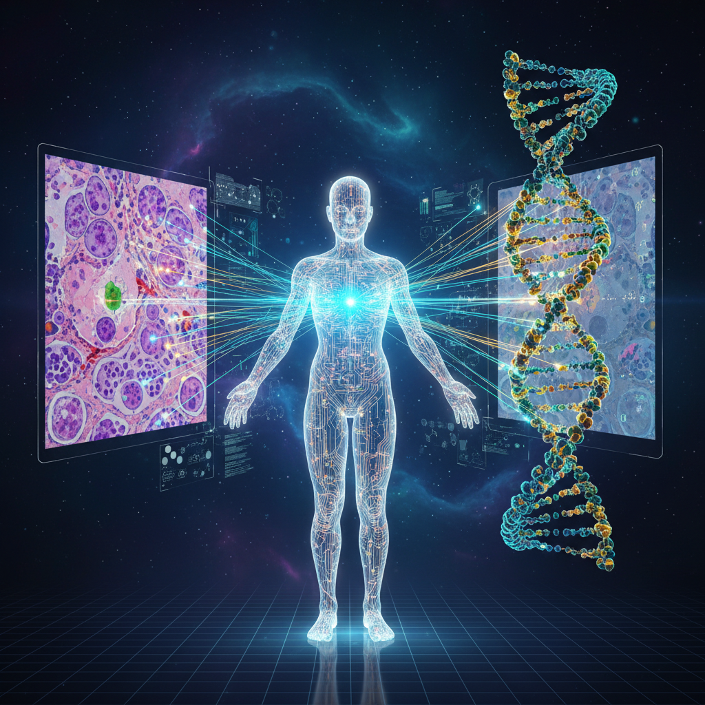

AI가 병리 이미지와 유전 정보를 동시에 분석하는 모습

### ’골든타임’을 잡는 1분의 혁신

암 치료는 시간과의 싸움입니다. 어떤 유전자 변이가 있는지 빨리 알아낼수록 환자에게 가장 잘 맞는 치료법을 신속하게 적용할 수 있습니다. 엑사원 패스는 2주가 걸리던 분석 시간을 1분으로 줄여, 의사가 환자의 ’골든타임’을 놓치지 않고 최적의 치료 계획을 세울 수 있도록 돕습니다.

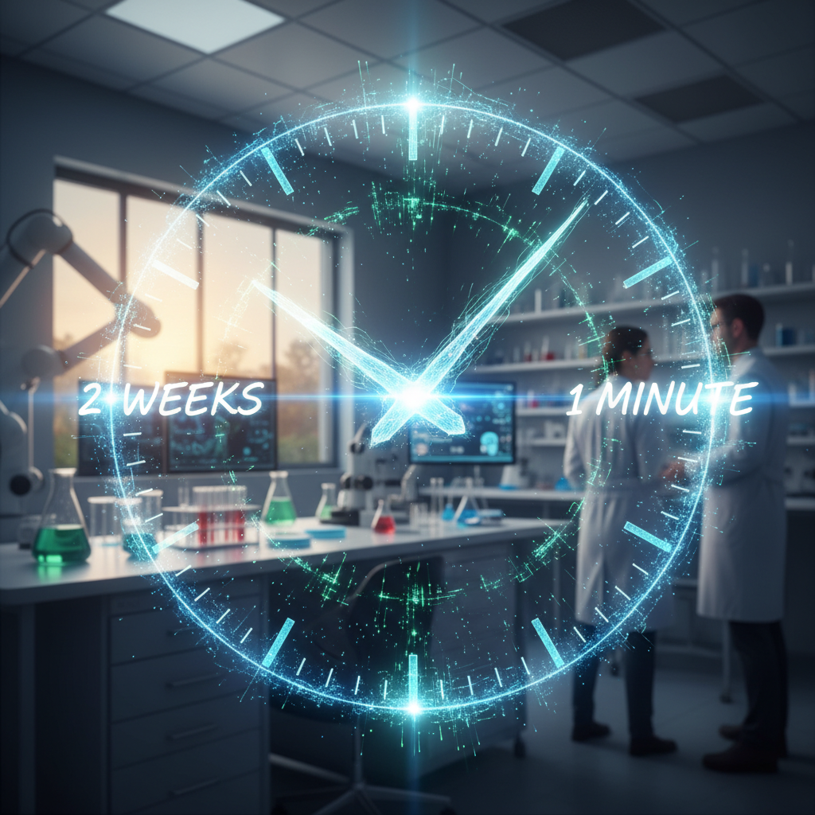

의료 환경에서 시간 단축의 중요성을 상징하는 이미지

### 협력으로 암 정복에 기여하다

LG AI 연구원은 엑사원 패스 모델을 세계 최대의 AI 커뮤니티인 ’허깅페이스’에 공개했습니다. 이는 더 많은 연구자들이 이 기술을 활용하여 다양한 암 종류에 대한 연구를 가속화하고, 전 세계적인 협력을 통해 암 정복이라는 공동의 목표에 더 빨리 다가가기 위함입니다.

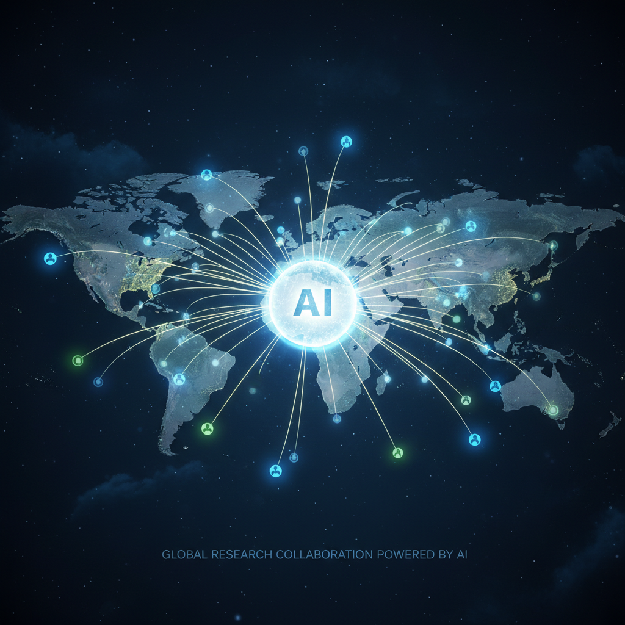

전 세계적인 AI 연구 협력을 상징하는 이미지

## 마무리

엑사원 패스는 AI 기술이 인류의 건강에 얼마나 직접적이고 긍정적인 영향을 미칠 수 있는지를 보여주는 놀라운 사례입니다. 진단 시간을 단축하고 정확도를 높여, ‘정밀 의료’ 시대를 한 걸음 더 가까이 가져오고 있습니다. AI와 함께라면 암과의 싸움에서 인류가 승리할 날도 머지않았습니다.

## 참고 자료

- [조선비즈](https://biz.chosun.com/it-science/ict/2024/05/13/2HT4XDSYABG5RO4D5OSM25YECU/)
- [시사저널e](http://www.sisajournal-e.com/news/articleView.html?idxno=404987)
- [THE AI](https://www.newstheai.com/news/articleView.html?idxno=28889)
- [데일리팝](http://www.dailypop.kr/news/articleView.html?idxno=77241)